# Segmented regression of age-standardised mortality rates - Scotland all-ages, period limited to permit comparison with ONS results for England

# Introduction

To undertake segmented regression (one and two-break models) for Scotland, all-ages, age-standardised mortality rates(ASMR). Employs a limited data range (Q4 1990-Q4 2017) in order to make the results comparable to those published by the ONS for England (see https://www.ons.gov.uk/releases/changingtrendsinmortalityinenglandandwales1990to2017experimentalstatistics) . Quarterly annual ASMR employ the 2013 European Standard Popualtion, and were provided by National Records for Scotland.

Contents:

*Load packages, load data, tidy data labels, and convert dates to identifiable quarters* Plot observed data *Generate, view and plot linear model* Run Davies test to identify and test signifcance of single break point *Generate and view one breakpoint segmented model* Extract breakpoints and confidence intervals *Plot one breakpoint model* Generate two break segmented model *Use AIC and BIC to compare fit of one and two break models* Plot two breakpoint model *Error bar plot as alternative approach to presenting breakpoint and confidence intervals

# Summary of findings

This analysis provides a means of assessing whether the breakpoints identified in age-standardised mortality rates for men and women in Scotland differ from those found in England.

The ONS analysis found the following results for England (see ONS_seg_replicationforQA.Rmd for replication) Male breakpoint: Q2 2011 to Q1 2012 (lower 95% CI Q3 2010 to Q2 2011; upper 95% CI Q1 2012 to Q4 2012) Female breakpoint: Q2 2013 to Q1 2014 (lower 95% CI Q1 2012 to Q4 2012; upper 95% CI Q3 2014 to Q2 2015)

Therefore although the breakpoints identified for Scotland are slightly later, the 95% confidence intervals overlap. A representation of the breakpoints obtained from different models (one and two-break), time periods, and geographies, can be found here: file://thesource.healthscotland.com/DavWWWRoot/collaboration/teams/phs/pho/Output/Summary findings from segmented regression.xlsx This shows that all the models find a breakpoint within the period Apr 2011 to Jun 2014, and that the 95% confidence intervals overlap for all these variants of analysis.

## Load packages

```r
#install.packages("pacman")
pacman::p_load(
  tidyverse,
  segmented,
  plotly,
  dplyr,
  readr,
  ggplot2,
  broom,
  tidyr
               )
```

## Load data and assign to object “data”

```r
data <- read.csv("Data/QuarterlyASMR1990_2018.csv")
data
```

| period | sex | allageesprate | allagestderr | allagelcli | allageucli | under75esprate | under75stderr | under75lcli | under75ucli | totdeaths |
| --- | --- | --- | --- | --- | --- | --- | --- | --- | --- | --- |
| 19901 | F | 1500.4002 | 7.788046 | 1485.1356 | 1515.6648 | 589.2652 | 4.994766 | 579.4755 | 599.0550 | 34163 |
| 19901 | M | 2287.7414 | 13.950236 | 2260.3990 | 2315.0839 | 1010.2307 | 7.222368 | 996.0749 | 1024.3866 | 31360 |
| 19901 | P | 1796.2713 | 6.854256 | 1782.8370 | 1809.7056 | 777.9763 | 4.242511 | 769.6609 | 786.2916 | 65523 |
| 19902 | F | 1499.6691 | 7.774313 | 1484.4314 | 1514.9067 | 590.4938 | 4.998890 | 580.6960 | 600.2917 | 34216 |
| 19902 | M | 2271.7785 | 13.869048 | 2244.5951 | 2298.9618 | 1002.3490 | 7.183408 | 988.2696 | 1016.4285 | 31247 |
| 19902 | P | 1790.5826 | 6.830757 | 1777.1943 | 1803.9709 | 775.1230 | 4.230873 | 766.8305 | 783.4155 | 65463 |
| 19903 | F | 1485.5072 | 7.730787 | 1470.3549 | 1500.6596 | 588.0220 | 4.985508 | 578.2504 | 597.7936 | 33997 |
| 19903 | M | 2252.7301 | 13.786253 | 2225.7090 | 2279.7512 | 993.3030 | 7.136414 | 979.3157 | 1007.2904 | 31069 |
| 19903 | P | 1774.0388 | 6.788831 | 1760.7327 | 1787.3450 | 770.2041 | 4.212956 | 761.9467 | 778.4615 | 65066 |
| 19904 | F | 1386.2319 | 7.495202 | 1371.5413 | 1400.9225 | 563.1330 | 4.878688 | 553.5707 | 572.6952 | 31910 |

[output cut: 332 more lines]

# Tidy periods into quarters, select all age rate, filter to M&F only, limit period to Q4 1990 - Q4 2017

Quarters assigned as follows: .125 = quarter 1, .375 = quarter 2, .625 = quarter 3, .875 = quarter 4. Quarter indicates last quarter in annual period i.e. ASMR for the year that includes that quarter and three preceding quarters. The period limitation matches the data points used by ONS in the publication identified in the introduction.

```r
data %>%
  separate(period, into = c("year","quarter"), sep = 4) %>%
  mutate(
   year = as.double(year),
   quarter = as.double(quarter)
  ) %>%
  mutate(
    time = year + (quarter / 4) - 0.125
  ) %>%
  select(time, sex, allageesprate)  %>%
  filter(time >= 1990.626, time <=2018.124, sex!="P")-> tidied_allagerates

tidied_allagerates
```

| time | sex | allageesprate |
| --- | --- | --- |
| 1990.875 | F | 1386.2319 |
| 1990.875 | M | 2114.4333 |
| 1991.125 | F | 1370.9937 |
| 1991.125 | M | 2090.4911 |
| 1991.375 | F | 1361.9806 |
| 1991.375 | M | 2081.5897 |
| 1991.625 | F | 1356.4288 |
| 1991.625 | M | 2074.8453 |
| 1991.875 | F | 1359.8080 |
| 1991.875 | M | 2077.0059 |

[output cut: 208 more lines]

# Plot quarterly-rolling annual age-standardised mortality rates by time

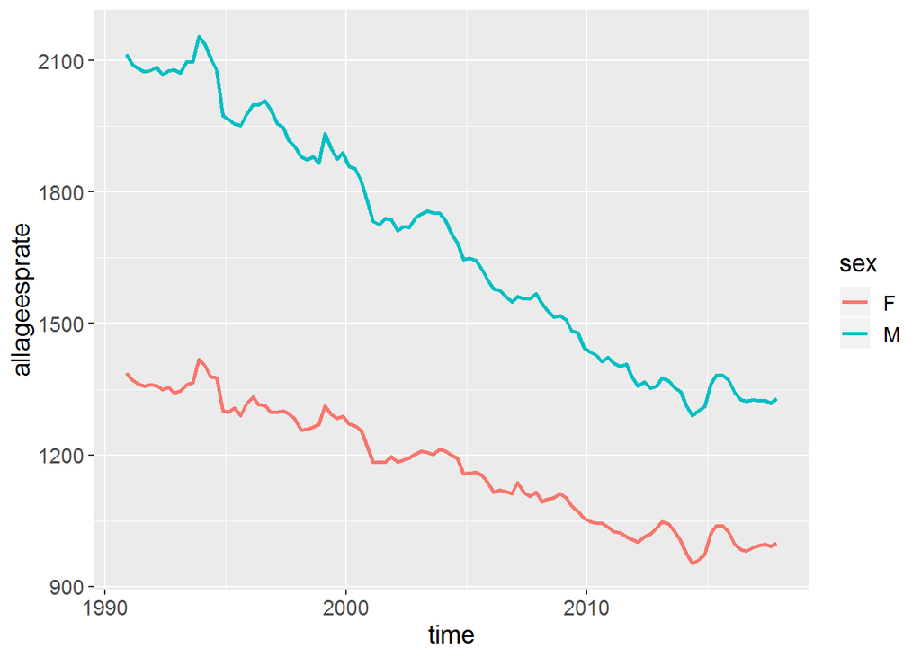

```r
plot<-ggplot(tidied_allagerates,aes(x=time,y=allageesprate, color=sex))+geom_line(size=1.0001, show.legend = TRUE)+theme(text=element_text(size=14))
plot
```

## Generate linear model for both sexes

```r
tidied_allagerates %>%
  rename(rate = allageesprate) %>%
  filter(sex == "M") -> allagemale
  lm(rate ~ time, data = allagemale) -> lmod_male

tidied_allagerates %>%
  rename(rate = allageesprate) %>%
  filter(sex == "F") -> allagefemale
  lm(rate ~ time, data = allagefemale) -> lmod_female
```

## View linear model

```r
summary (lmod_male)
```

```
##
## Call:
## lm(formula = rate ~ time, data = allagemale)
##
## Residuals:
##    Min     1Q Median     3Q    Max
## -63.76 -33.29 -14.55  37.56 114.02
##
## Coefficients:
##               Estimate Std. Error t value Pr(>|t|)
## (Intercept) 69816.4412  1094.7192   63.78   <2e-16 ***
## time          -33.9917     0.5462  -62.24   <2e-16 ***
## ---
## Signif. codes:  0 '***' 0.001 '**' 0.01 '*' 0.05 '.' 0.1 ' ' 1
##
## Residual standard error: 44.85 on 107 degrees of freedom
## Multiple R-squared:  0.9731, Adjusted R-squared:  0.9729
## F-statistic:  3874 on 1 and 107 DF,  p-value: < 2.2e-16
```

```r
summary (lmod_female)
```

```
##
## Call:
## lm(formula = rate ~ time, data = allagefemale)
##
## Residuals:
##     Min      1Q  Median      3Q     Max
## -54.460 -20.349  -1.227  18.397  72.332
##
## Coefficients:
##               Estimate Std. Error t value Pr(>|t|)
## (Intercept) 34259.1460   659.7946   51.92   <2e-16 ***
## time          -16.5072     0.3292  -50.15   <2e-16 ***
## ---
## Signif. codes:  0 '***' 0.001 '**' 0.01 '*' 0.05 '.' 0.1 ' ' 1
##
## Residual standard error: 27.03 on 107 degrees of freedom
## Multiple R-squared:  0.9592, Adjusted R-squared:  0.9588
## F-statistic:  2515 on 1 and 107 DF,  p-value: < 2.2e-16
```

## Fit trend line of linear model to whole time series

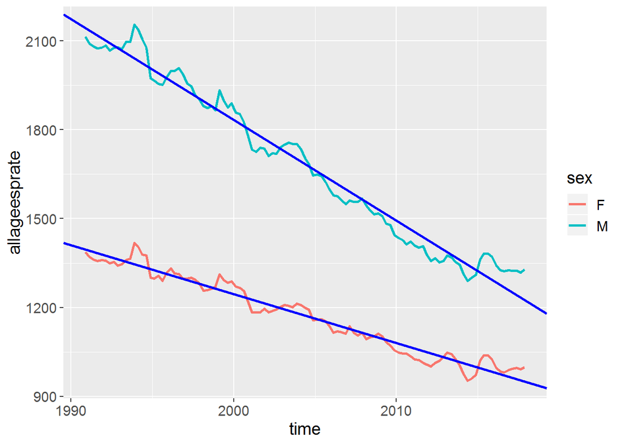

```r
my.coeftrendlinemale <- coef(lmod_male)
my.coeftrendlinefemale <- coef(lmod_female)
addtrendline <- plot + geom_abline(intercept = my.coeftrendlinemale[1], col="Blue", size=1.0001,
                                       slope = my.coeftrendlinemale[2],
                                       aes(colour = "Overall"))+
  geom_abline(intercept = my.coeftrendlinefemale[1], col="Blue", size=1.0001,
                                       slope = my.coeftrendlinefemale[2],
                                       aes(colour = "Overall"))
addtrendline
```

# Segmented regression

## Davies test, to test for teh significance of a breakpoint at each of the 107 possible data points

This identifies 2013.6 as the most significant breakpoint for men, hence within quarter 3 2013, indicating the year Oct 2012-Sep 2013. For women the result is 2014.4, hence within quarter 2 2014, indicating the year July 2013-June 2014.

```r
davies_allmale = davies.test(lmod_male, ~time, k=107)
davies_allfemale = davies.test(lmod_female, ~time, k=107)
davies_allmale
```

```
##
##  Davies' test for a change in the slope
##
## data:  formula = rate ~ time ,   method = lm
## model = gaussian , link = identity
## segmented variable = time
## 'best' at = 2013.6, n.points = 105, p-value = 6.349e-12
## alternative hypothesis: two.sided
```

```r
davies_allfemale
```

```
##
##  Davies' test for a change in the slope
##
## data:  formula = rate ~ time ,   method = lm
## model = gaussian , link = identity
## segmented variable = time
## 'best' at = 2014.4, n.points = 105, p-value = 4.674e-05
## alternative hypothesis: two.sided
```

## Segmented regression function - one break point

The result for women is the same as that found using the full data range available. The result for men is one quarter later, but with overlapping 95% confidence intervals.

```r
 my.seg_male<-segmented(  lmod_male, seg_rate.Z = ~time, psi = NA, control = seg.control(K=1))
 my.seg_female<-segmented(  lmod_female, seg_rate.Z = ~time, psi = NA, control = seg.control(K=1))

summary(my.seg_male)
```

```
##
##  ***Regression Model with Segmented Relationship(s)***
##
## Call:
## segmented.lm(obj = lmod_male, psi = NA, control = seg.control(K = 1),
##     seg_rate.Z = ~time)
##
## Estimated Break-Point(s):
##      Est.   St.Err
## 2013.292    0.520
##
## Meaningful coefficients of the linear terms:
##              Estimate Std. Error t value Pr(>|t|)
## (Intercept) 75113.120   1131.136  66.405   <2e-16 ***
## time          -36.641      0.565 -64.851   <2e-16 ***
## U1.time        33.449      5.860   5.708       NA
## ---
## Signif. codes:  0 '***' 0.001 '**' 0.01 '*' 0.05 '.' 0.1 ' ' 1
##
## Residual standard error: 34.81 on 105 degrees of freedom
## Multiple R-Squared: 0.9841,  Adjusted R-squared: 0.9837
##
## Convergence attained in 2 iterations with relative change 1.143567e-16
```

```r
summary(my.seg_female)
```

```
##
##  ***Regression Model with Segmented Relationship(s)***
##
## Call:
## segmented.lm(obj = lmod_female, psi = NA, control = seg.control(K = 1),
##     seg_rate.Z = ~time)
##
## Estimated Break-Point(s):
##      Est.   St.Err
## 2014.380    0.758
##
## Meaningful coefficients of the linear terms:
##              Estimate Std. Error t value Pr(>|t|)
## (Intercept) 36122.088    732.938  49.284   <2e-16 ***
## time          -17.439      0.366 -47.649   <2e-16 ***
## U1.time        19.326      6.496   2.975       NA
## ---
## Signif. codes:  0 '***' 0.001 '**' 0.01 '*' 0.05 '.' 0.1 ' ' 1
##
## Residual standard error: 24.46 on 105 degrees of freedom
## Multiple R-Squared: 0.9672,  Adjusted R-squared: 0.9663
##
## Convergence attained in 15 iterations with relative change 0
```

## Extract breakpoint and 95% confidence intervals for one break model

The standard error is used to calcuate an upper and lower 95% confidence intervals. These are presented below.

```r
breakpointmale <- my.seg_male$psi[, 2]
breakpointfemale <- my.seg_female$psi[, 2]
breakpoint_SEmale <- my.seg_male$psi[, 3]
breakpoint_SEfemale <- my.seg_female$psi[, 3]
breakpoint_low_CImale <- breakpointmale - (breakpoint_SEmale*1.96)
breakpoint_up_CImale <- breakpointmale + (breakpoint_SEmale*1.96)
breakpoint_low_CIfemale <- breakpointfemale - (breakpoint_SEfemale*1.96)
breakpoint_up_CIfemale <- breakpointfemale + (breakpoint_SEfemale*1.96)

breakpointmale
```

```
## [1] 2013.292
```

```r
breakpoint_low_CImale
```

```
## [1] 2012.272
```

```r
breakpoint_up_CImale
```

```
## [1] 2014.313
```

```r
breakpointfemale
```

```
## [1] 2014.38
```

```r
breakpoint_low_CIfemale
```

```
## [1] 2012.894
```

```r
breakpoint_up_CIfemale
```

```
## [1] 2015.866
```

## Generate and plot predicted values from one break model

The ‘fitted’ function is used to predict values for ASMR based on the one break segmented regression model. These predicted values are plotted below.

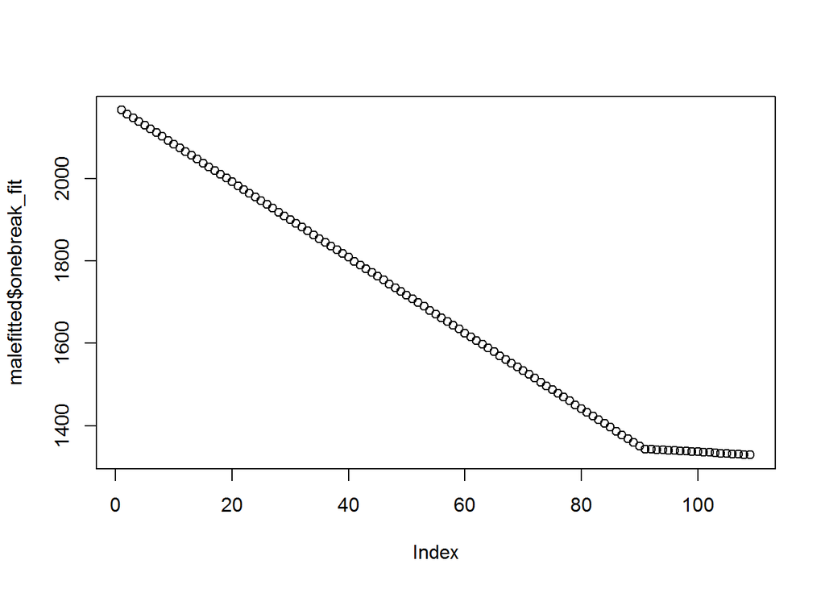

```r
tidied_allagerates %>%
  filter(sex == "M") %>%
  mutate(
    onebreak_fit = fitted(
      my.seg_male

      )
    ) -> malefitted

tidied_allagerates %>%
  filter(sex == "F") %>%
  mutate(
    onebreak_fit = fitted(
      my.seg_female

      )
    ) -> femalefitted
plot(malefitted$onebreak_fit)
```

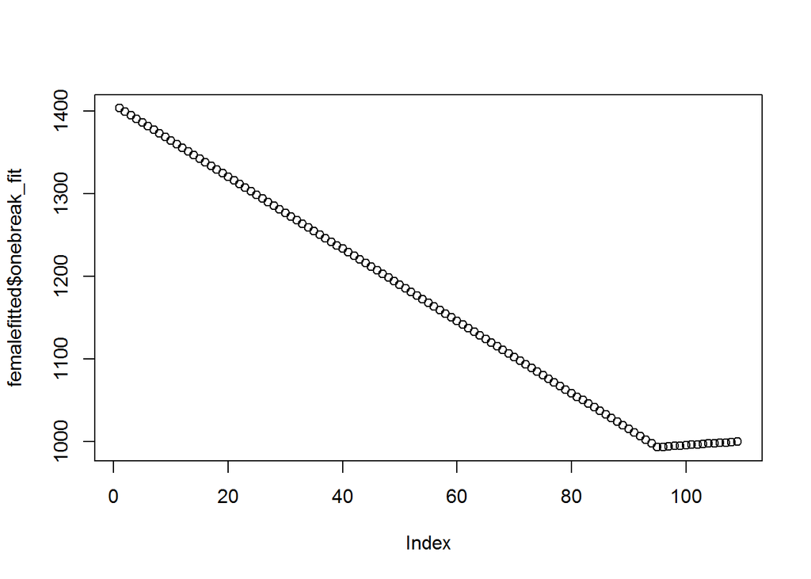

```r
plot(femalefitted$onebreak_fit)
```

## Combine male and female observed and predicted values in single data frame

```r
femalefitted %>%
  select(
    time, sex, observed = allageesprate,
    predicted = onebreak_fit
  ) %>%
  bind_rows(
    malefitted %>%
      select(
        time, sex, observed = allageesprate,
        predicted = onebreak_fit
      )
  ) -> obs_fit_both
```

## Plot observed values with linear and segmented models

The observed data are presented as data points, and the lines indicate the predicted values, according to the one break segmented model.

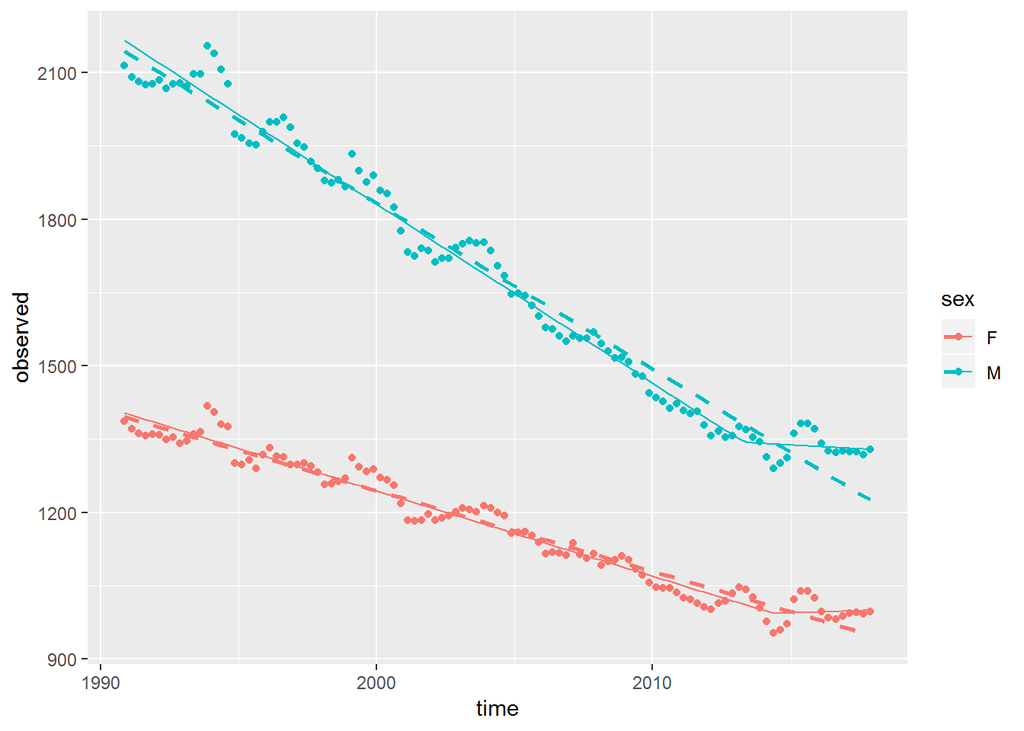

```r
obs_fit_both %>%
  ggplot(
    aes (x=time, color=sex)
  ) +
  geom_point(
    aes (y=observed)) +
  geom_line (
    aes (y=predicted)) +
  stat_smooth(method="lm",se=F,linetype="dashed",
    aes (y=observed)
  )
```

## Getsegmented regression coefficients

Coefficients are used in order to be able to plot a continuation of the pre-break point trend. This differs slightly from the overall linear model, as it does not include the post-breakpoint data.

```r
coef(my.seg_male)
```

```
## (Intercept)        time     U1.time   psi1.time
## 75113.11984   -36.64106    33.44853     0.00000
```

```r
coef(my.seg_female)
```

```
## (Intercept)        time     U1.time   psi1.time
## 36122.08819   -17.43900    19.32574     0.00000
```

```r
 # Get coeffiencents male
  b0_aspec_m <- coef(my.seg_male)[[1]]
  b1_aspec_m <- coef(my.seg_male)[[2]]
  c1_aspec_m <- coef(my.seg_male)[[2]] + coef(my.seg_male)[[3]]

  break1_aspec_m <- my.seg_male$psi[[2]]

  # Get coefficients female
    b0_aspec_f <- coef(my.seg_female)[[1]]
  b1_aspec_f <- coef(my.seg_female)[[2]]
  c1_aspec_f <- coef(my.seg_female)[[2]] + coef(my.seg_female)[[3]]

  break1_aspec_f <- my.seg_female$psi[[2]]
```

## Annotated plot of observed data, segmented model, and continutation of pre-breakpoint trend

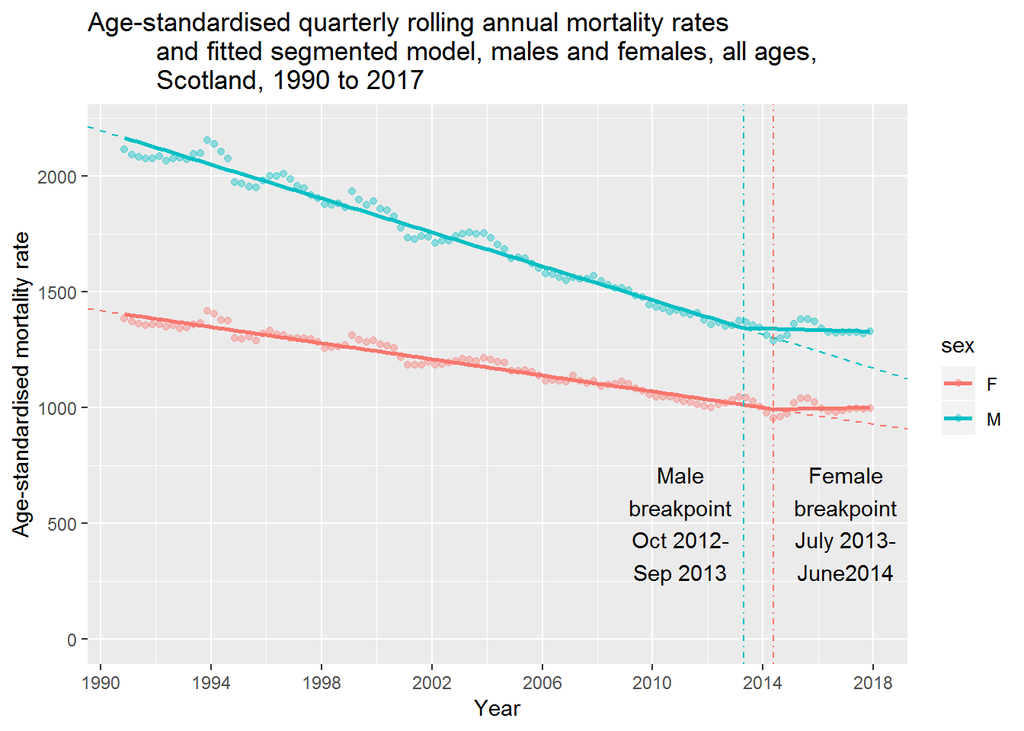

```r
# plot
 p <- obs_fit_both %>%
  ggplot(
    aes (x=time, color=sex)
  ) +
  geom_point(
    aes (y=observed), alpha=0.4) +
  geom_line (
    aes (y=predicted), size=1) +
  geom_abline(intercept = b0_aspec_m, slope = b1_aspec_m, color="#00BFC4", linetype="dashed") +
    geom_abline(intercept = b0_aspec_f, slope = b1_aspec_f, color="#F8766D", linetype= "dashed") +
    ylim(0,2200)+
    labs(x="Year", y="Age-standardised mortality rate", title =
        "Age-standardised quarterly rolling annual mortality rates
         and fitted segmented model, males and females, all ages,
         Scotland, 1990 to 2017") +
    scale_x_continuous (breaks=c(1990, 1994, 1998, 2002, 2006, 2010, 2014, 2018))+
    geom_vline(xintercept = my.seg_male[["psi"]][[2]], color = "#00BFC4", linetype="dotdash")+
    geom_vline(xintercept = my.seg_female[["psi"]][[2]], color = "#F8766D", linetype="dotdash") +
   annotate(geom="text", x=2011, y=500, label="Male\nbreakpoint\nOct 2012-\n Sep 2013 ")+
   annotate(geom="text", x=2017, y=500, label="Female\nbreakpoint\nJuly 2013-\nJune2014")


 plot(p)
```

```r
    ggsave (
    "Figures/Segmentedplot_Scotland_Allages.png", height=15, width=20, units="cm")
```

## Build up chart layers

Sequential charts to allow presentation of how model is generated and fitted.

```r
observedplot <- obs_fit_both %>%
  ggplot(
    aes (x=time, color=sex)
  ) +
  geom_point(
    aes (y=observed), alpha=0.4)+
   ylim(0,2200)+
    labs(x="Year", y="Age-standardised mortality rate", title =
        "Age-standardised quarterly rolling annual mortality rates", subtitles="males and females, all ages, Scotland, 1990 to 2017")+
  scale_x_continuous (breaks=c(1990, 1994, 1998, 2002, 2006, 2010, 2014, 2018))

ggsave (
    "Figures/observedplot_Scotland_Allages.png", height=15, width=20, units="cm")


linearplot <- obs_fit_both %>%
  ggplot(
    aes (x=time, color=sex)
  ) +
  geom_point(
    aes (y=observed), alpha=0.4)+
  geom_abline(intercept = my.coeftrendlinemale[1], col="#00BFC4", size=1.0001,
                                       slope = my.coeftrendlinemale[2])+
  geom_abline(intercept = my.coeftrendlinefemale[1], col="#F8766D", size=1.0001,
                                       slope = my.coeftrendlinefemale[2])+
   ylim(0,2200)+
    labs(x="Year", y="Age-standardised mortality rate", title = "Age-standardised quarterly rolling annual mortality rates", subtitles="males and females, all ages, Scotland, 1990 to 2017: linear model fitted"
        )+
  scale_x_continuous (breaks=c(1990, 1994, 1998, 2002, 2006, 2010, 2014, 2018))

    ggsave (
    "Figures/linearplot_Scotland_Allages.png", height=15, width=20, units="cm")

segmentedplot <- obs_fit_both %>%
  ggplot(
    aes (x=time, color=sex)
  ) +
  geom_point(
    aes (y=observed), alpha=0.4)+
  geom_line (
    aes (y=predicted), size=1) +
  #geom_abline(intercept = b0_aspec_m, slope = b1_aspec_m, color="#00BFC4", linetype="dashed") +
   # geom_abline(intercept = b0_aspec_f, slope = b1_aspec_f, color="#F8766D", linetype= "dashed") +
    ylim(0,2200)+
    labs(x="Year", y="Age-standardised mortality rate", title = "Age-standardised quarterly rolling annual mortality rates", subtitles="males and females, all ages, Scotland, 1990 to 2017: one-break segmented model fitted")+
  scale_x_continuous (breaks=c(1990, 1994, 1998, 2002, 2006, 2010, 2014, 2018))

    ggsave (
    "Figures/segmentedplotonly_Scotland_Allages.png", height=15, width=20, units="cm")

annotatedsegmentedplot <- obs_fit_both %>%
  ggplot(
    aes (x=time, color=sex)
  ) +
  geom_point(
    aes (y=observed), alpha=0.4)+
  geom_line (
    aes (y=predicted), size=1) +
  geom_abline(intercept = b0_aspec_m, slope = b1_aspec_m, color="#00BFC4", linetype="dashed") +
  geom_abline(intercept = b0_aspec_f, slope = b1_aspec_f, color="#F8766D", linetype= "dashed") +
    ylim(0,2200)+
    labs(x="Year", y="Age-standardised mortality rate", title = "Age-standardised quarterly rolling annual mortality rates", subtitles="males and females, all ages, Scotland, 1990 to 2017:
         one-break segmented model and continuation of previous trend")+
  scale_x_continuous (breaks=c(1990, 1994, 1998, 2002, 2006, 2010, 2014, 2018))+
      geom_vline(xintercept = my.seg_male[["psi"]][[2]], color = "#00BFC4", linetype="dotdash")+
    geom_vline(xintercept = my.seg_female[["psi"]][[2]], color = "#F8766D", linetype="dotdash") +
   annotate(geom="text", x=2011, y=250, label="Male\nbreakpoint\nOct 2012-\n Sep 2013 ")+
   annotate(geom="text", x=2017, y=250, label="Female\nbreakpoint\nJuly 2013-\nJune2014")

    ggsave (
    "Figures/annontatedsegmentedplot_Scotland_Allages.png", height=15, width=20, units="cm")
```

## Segmented regression with two breakpoints

The time period identified for the later breakpoint is, in this case, altered from the one breakpoint model. The later breakpoint here is quarter 3 2012 for men (Oct 2011-Sep 2012), and quarter 1 2012 for women (Apr 2011-Mar 2012).

```r
my.seg_male2 <-segmented( lmod_male, seg_rate.Z = ~timepoint, psi = NA, control = seg.control(K=2))
my.seg_female2<- segmented(lmod_female, seg_rate.Z = ~timepoint, psi = NA, control = seg.control(K=2))

summary(my.seg_male2)
```

```
##
##  ***Regression Model with Segmented Relationship(s)***
##
## Call:
## segmented.lm(obj = lmod_male, psi = NA, control = seg.control(K = 2),
##     seg_rate.Z = ~timepoint)
##
## Estimated Break-Point(s):
##                Est. St.Err
## psi1.time 1993.833  0.543
## psi2.time 2012.658  0.455
##
## Meaningful coefficients of the linear terms:
##              Estimate Std. Error t value Pr(>|t|)
## (Intercept)  7167.603  20241.102   0.354    0.724
## time           -2.552     10.160  -0.251    0.802
## U1.time       -36.081     10.180  -3.544       NA
## U2.time        33.537      4.424   7.580       NA
##
## Residual standard error: 30.37 on 103 degrees of freedom
## Multiple R-Squared: 0.9881,  Adjusted R-squared: 0.9876
##
## Convergence attained in 4 iterations with relative change 0
```

```r
summary(my.seg_female2)
```

```
##
##  ***Regression Model with Segmented Relationship(s)***
##
## Call:
## segmented.lm(obj = lmod_female, psi = NA, control = seg.control(K = 2),
##     seg_rate.Z = ~timepoint)
##
## Estimated Break-Point(s):
##                Est. St.Err
## psi1.time 1999.387  1.626
## psi2.time 2012.073  0.779
##
## Meaningful coefficients of the linear terms:
##              Estimate Std. Error t value Pr(>|t|)
## (Intercept) 28235.115   3129.527   9.022 1.10e-14 ***
## time          -13.487      1.569  -8.598 9.52e-14 ***
## U1.time        -6.317      1.818  -3.475       NA
## U2.time        14.798      2.912   5.081       NA
## ---
## Signif. codes:  0 '***' 0.001 '**' 0.01 '*' 0.05 '.' 0.1 ' ' 1
##
## Residual standard error: 23.43 on 103 degrees of freedom
## Multiple R-Squared: 0.9705,  Adjusted R-squared: 0.9691
##
## Convergence attained in 6 iterations with relative change 0
```

## AIC and BIC to compare one and two break models

The lower AIC and BIC indicate that the two break models are a better fit than the one break model for both males and females.

```r
AIC(my.seg_male, my.seg_male2)
```

|  | df | AIC |
| --- | --- | --- |
| my.seg_male | 5 | 1089.148 |
| my.seg_male2 | 7 | 1061.317 |

```r
AIC(my.seg_female, my.seg_female2)
```

|  | df | AIC |
| --- | --- | --- |
| my.seg_female | 5 | 1012.167 |
| my.seg_female2 | 7 | 1004.738 |

```r
BIC(my.seg_male, my.seg_male2)
```

|  | df | BIC |
| --- | --- | --- |
| my.seg_male | 5 | 1102.605 |
| my.seg_male2 | 7 | 1080.157 |

```r
BIC(my.seg_female, my.seg_female2)
```

|  | df | BIC |
| --- | --- | --- |
| my.seg_female | 5 | 1025.624 |
| my.seg_female2 | 7 | 1023.577 |

## Extract breakpoint and calcuate 95% confidence intervals for two break model

The breakpoint in the 2010’s occurs slightly earlier in this two break model, however the 95% confidence intervals overlap with those identified in the one break model, and with those identified in the analysis using the full data range to 2018. They confidence intervals also overlap with the all age breakpoint findings published by ONS for England.

```r
#CI for first male breakpoint
breakpoint1male_2break <- my.seg_male2$psi[3]
breakpoint1_SEmale_2break <- my.seg_male2$psi[5]
breakpoint1male_lowCI_2break <- breakpoint1male_2break - (breakpoint1_SEmale_2break*1.96)
breakpoint1male_upCI_2break <- breakpoint1male_2break + (breakpoint1_SEmale_2break*1.96)

breakpoint1male_2break
```

```
## [1] 1993.833
```

```r
breakpoint1male_lowCI_2break
```

```
## [1] 1992.769
```

```r
breakpoint1male_upCI_2break
```

```
## [1] 1994.897
```

```r
#CI for second male breakpoint
breakpoint2male_2break <- my.seg_male2$psi[4]
breakpoint2_SEmale_2break <- my.seg_male2$psi[6]
breakpoint2male_lowCI_2break <- breakpoint2male_2break - (breakpoint2_SEmale_2break*1.96)
breakpoint2male_upCI_2break <- breakpoint2male_2break + (breakpoint2_SEmale_2break*1.96)

breakpoint2male_2break
```

```
## [1] 2012.658
```

```r
breakpoint2male_lowCI_2break
```

```
## [1] 2011.765
```

```r
breakpoint2male_upCI_2break
```

```
## [1] 2013.55
```

```r
#CI for first female breakpoint
breakpoint1female_2break <- my.seg_female2$psi[3]
breakpoint1_SEfemale_2break <- my.seg_female2$psi[5]
breakpoint1female_lowCI_2break <- breakpoint1female_2break - (breakpoint1_SEfemale_2break*1.96)
breakpoint1female_upCI_2break <- breakpoint1female_2break + (breakpoint1_SEfemale_2break*1.96)

breakpoint1female_2break
```

```
## [1] 1999.387
```

```r
breakpoint1female_lowCI_2break
```

```
## [1] 1996.2
```

```r
breakpoint1female_upCI_2break
```

```
## [1] 2002.574
```

```r
#CI for second female breakpoint
breakpoint2female_2break <- my.seg_female2$psi[4]
breakpoint2_SEfemale_2break <- my.seg_female2$psi[60]
breakpoint2female_lowCI_2break <- breakpoint2female_2break - (breakpoint2_SEfemale_2break*1.96)
breakpoint2female_upCI_2break <- breakpoint2female_2break + (breakpoint2_SEfemale_2break*1.96)

breakpoint2female_2break
```

```
## [1] 2012.073
```

```r
breakpoint2female_lowCI_2break
```

```
## [1] NA
```

```r
breakpoint2female_upCI_2break
```

```
## [1] NA
```